# 基于 LSTM 的宋诗生成

**姓名：李伟龙** **学号：SA25214030**

## 实验目标

本实验使用宋诗数据集训练字符级 LSTM 语言模型，实现：

1. 古诗数据读取
2. 七言绝句筛选
3. 模型训练
4. 基于起始词生成古诗

模型以“明月”为起始词生成固定格式古诗。

```python
import json
import re
import random
from pathlib import Path

import numpy as np
import matplotlib.pyplot as plt

import torch
import torch.nn as nn

from torch.utils.data import Dataset, DataLoader

seed = 42
random.seed(seed)
np.random.seed(seed)
torch.manual_seed(seed)
device = torch.device("cuda" if torch.cuda.is_available() else "cpu")

print(device)
```

```
cuda
```

## 数据读取

实验使用 `poet.song.40000.json` 到 `poet.song.43000.json`中的宋诗数据。

```python
data_dir = Path("data")

json_files = sorted(data_dir.glob("poet.song.*.json"))

data = []

for file in json_files:
    with open(file, "r", encoding="utf-8") as f:
        part = json.load(f)
        data.extend(part)

        print(f"{file.name}: {len(part)}")

print("总数据量:", len(data))
print(data[0])

all_poems = []

for item in data:
    paragraphs = item.get("paragraphs", [])
    all_poems.append(paragraphs)

print("诗歌数量:", len(all_poems))
print(all_poems[0])
```

```
poet.song.40000.json: 1000
poet.song.41000.json: 1000
poet.song.42000.json: 1000
poet.song.43000.json: 1000
总数据量: 4000
{'author': '釋義青', 'paragraphs': ['於道無所證，方通萬法路。', '或明或暗行，不慎亦不護。', '月來松色寒，雲去青山露。', '今古天台橋，幾人能得度。'], 'title': '第九十四多子塔前頌', 'id': '3a1eba1b-d886-417b-9f4e-c992246fb89c'}
诗歌数量: 4000
['於道無所證，方通萬法路。', '或明或暗行，不慎亦不護。', '月來松色寒，雲去青山露。', '今古天台橋，幾人能得度。']
```

## 数据预处理

为了生成固定格式古诗，本实验筛选每句七字的七言绝句。

```python
def clean_line(line):
    line = line.strip()

    line = re.sub(
        r"[，。！？、；：,.!?;:\s]",
        "",
        line
    )

    return line


def is_qiyan_jueju(paragraphs):
    # 数据中七言绝句通常是 2 个 paragraph，每个 paragraph 包含两句七言
    if len(paragraphs) != 2:
        return False

    full_text = "".join(paragraphs)

    for line in paragraphs:
        line = clean_line(line)

        # 每个 paragraph 去掉标点后应为 14 字
        if len(line) != 14:
            return False

    return True

qiyan_poems = []

for paragraphs in all_poems:

    if is_qiyan_jueju(paragraphs):

        poem = ""

        for line in paragraphs:
            poem += clean_line(line)

        qiyan_poems.append(poem)

print("七言绝句数量:", len(qiyan_poems))

print(qiyan_poems[:5])

START_TOKEN = "<"
END_TOKEN = ">"

poems = []

for poem in qiyan_poems:
    poems.append(
        START_TOKEN + poem + END_TOKEN
    )

print(poems[0])
```

```
七言绝句数量: 906
['輕輕人問玄中旨便吐肝腸說與他木人暗皺雙眉處石女多言爭奈何', '圓缺曾伸問老翁石龜銜子引清風昨朝木馬潭中過踏出金烏半夜紅', '有無今古兩重關正眼禪人過者難欲通大道長安路莫聽崑崙敘往還', '雲淡風輕近午天望花隨柳過前川旁人不識予心樂將謂偷閑學少年', '吏身拘絆同疏屬俗眼塵昏甚瞽矇辜負終南好泉石一年一度到山中']
<輕輕人問玄中旨便吐肝腸說與他木人暗皺雙眉處石女多言爭奈何>
```

## 字符词表构建

神经网络无法直接处理汉字，因此需要：字符 → 数字的映射。

```python
all_text = "".join(poems)

chars = sorted(list(set(all_text)))

char2idx = {
    char: idx
    for idx, char in enumerate(chars)
}

idx2char = {
    idx: char
    for char, idx in char2idx.items()
}

vocab_size = len(chars)

print("词表大小:", vocab_size)

print(chars[:20])

text = "明月"

ids = [char2idx[c] for c in text]

print(ids)

recover_text = "".join(
    [idx2char[i] for i in ids]
)

print(recover_text)
```

```
词表大小: 2833
['<', '>', '□', '㾓', '一', '丁', '七', '丈', '三', '上', '下', '不', '且', '丕', '世', '丘', '並', '中', '丹', '主']
[1032, 1080]
明月
```

## Dataset 构建

训练目标：输入前面的字符，预测下一个字符。

```python
class PoetryDataset(Dataset):

    def __init__(self, poems, char2idx):

        self.samples = []

        for poem in poems:

            ids = [
                char2idx[c]
                for c in poem
            ]

            x = ids[:-1]
            y = ids[1:]

            self.samples.append((x, y))

    def __len__(self):
        return len(self.samples)

    def __getitem__(self, idx):

        x, y = self.samples[idx]

        return (
            torch.tensor(x, dtype=torch.long),
            torch.tensor(y, dtype=torch.long)
        )

dataset = PoetryDataset(poems,char2idx)

dataloader = DataLoader(dataset,batch_size=64,shuffle=True)

x, y = next(iter(dataloader))

print(x.shape)
print(y.shape)
```

```
torch.Size([64, 29])
torch.Size([64, 29])
```

## LSTM 模型

本实验采用 LSTM（Long Short-Term Memory）作为序列建模网络。LSTM 属于循环神经网络（RNN）的一种改进结构，能够有效缓解：长序列梯度消失和长期依赖难以学习等问题。

模型结构如下：

```
Token ID
→ Embedding
→ LSTM
→ Linear
→ Softmax
```

```python
class PoetryLSTM(nn.Module):

    def __init__(
        self,
        vocab_size,
        embed_dim=128,
        hidden_dim=256,
        num_layers=2
    ):

        super().__init__()

        self.embedding = nn.Embedding(
            vocab_size,
            embed_dim
        )

        self.lstm = nn.LSTM(
            input_size=embed_dim,
            hidden_size=hidden_dim,
            num_layers=num_layers,
            batch_first=True,
            dropout=0.2
        )

        self.fc = nn.Linear(
            hidden_dim,
            vocab_size
        )

    def forward(self, x, hidden=None):

        x = self.embedding(x)

        output, hidden = self.lstm(
            x,
            hidden
        )

        logits = self.fc(output)

        return logits, hidden

model = PoetryLSTM(vocab_size)

model = model.to(device)

criterion = nn.CrossEntropyLoss()

optimizer = torch.optim.Adam(
    model.parameters(),
    lr=0.001
)

print(model)
```

```
PoetryLSTM(
  (embedding): Embedding(2833, 128)
  (lstm): LSTM(128, 256, num_layers=2, batch_first=True, dropout=0.2)
  (fc): Linear(in_features=256, out_features=2833, bias=True)
)
```

## 模型训练

本实验采用交叉熵损失函数（Cross Entropy Loss）进行训练。训练目标是最小化预测字符与真实字符之间的误差。优化器采用 Adam， 在训练过程中：输入字符序列；LSTM 输出每个位置的预测；与真实下一个字符计算交叉熵；反向传播更新参数； 随着训练进行，模型逐渐学习古诗中的字符组合规律与语言风格。 训练过程中记录每个 epoch 的平均 loss，并绘制 Loss 曲线观察模型收敛情况。

```
Epoch [1/300] Loss: 7.5963
Epoch [2/300] Loss: 6.9494
Epoch [3/300] Loss: 6.8898
Epoch [4/300] Loss: 6.8680
Epoch [5/300] Loss: 6.8533
Epoch [6/300] Loss: 6.8224
Epoch [7/300] Loss: 6.7900
Epoch [8/300] Loss: 6.7580
Epoch [9/300] Loss: 6.7266
Epoch [10/300] Loss: 6.7066
Epoch [11/300] Loss: 6.6609
Epoch [12/300] Loss: 6.6407
Epoch [13/300] Loss: 6.6104
Epoch [14/300] Loss: 6.5849
Epoch [15/300] Loss: 6.5627
Epoch [16/300] Loss: 6.5450
Epoch [17/300] Loss: 6.5105
Epoch [18/300] Loss: 6.4818
Epoch [19/300] Loss: 6.4547
Epoch [20/300] Loss: 6.4261
Epoch [21/300] Loss: 6.3786
Epoch [22/300] Loss: 6.3528
Epoch [23/300] Loss: 6.3002
Epoch [24/300] Loss: 6.2771
Epoch [25/300] Loss: 6.2457
Epoch [26/300] Loss: 6.1994
Epoch [27/300] Loss: 6.1510
Epoch [28/300] Loss: 6.0948
Epoch [29/300] Loss: 6.0530
Epoch [30/300] Loss: 5.9971
Epoch [31/300] Loss: 5.9497
Epoch [32/300] Loss: 5.9142
Epoch [33/300] Loss: 5.8596
Epoch [34/300] Loss: 5.7977
Epoch [35/300] Loss: 5.7187
Epoch [36/300] Loss: 5.6788
Epoch [37/300] Loss: 5.6106
Epoch [38/300] Loss: 5.5439
Epoch [39/300] Loss: 5.4856
Epoch [40/300] Loss: 5.4267
```

[output cut: 245 more lines]

```
Epoch [286/300] Loss: 0.3068
Epoch [287/300] Loss: 0.3031
Epoch [288/300] Loss: 0.3007
Epoch [289/300] Loss: 0.2985
Epoch [290/300] Loss: 0.2950
Epoch [291/300] Loss: 0.2926
Epoch [292/300] Loss: 0.2909
Epoch [293/300] Loss: 0.2903
Epoch [294/300] Loss: 0.2905
Epoch [295/300] Loss: 0.2914
Epoch [296/300] Loss: 0.2896
Epoch [297/300] Loss: 0.2893
Epoch [298/300] Loss: 0.2879
Epoch [299/300] Loss: 0.2866
Epoch [300/300] Loss: 0.2865
```

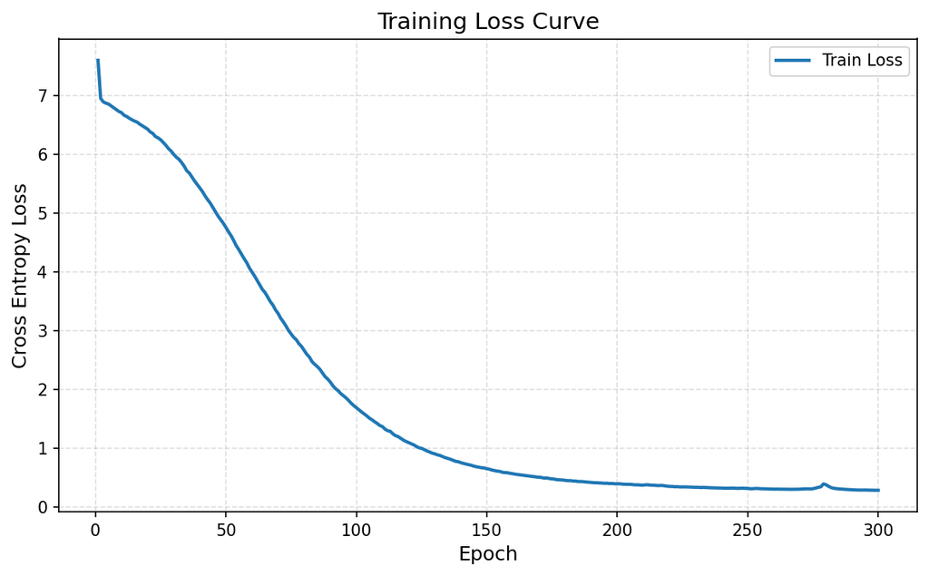

```python
num_epochs = 300

train_losses = []

for epoch in range(num_epochs):

    model.train()

    total_loss = 0

    for x, y in dataloader:

        x = x.to(device)
        y = y.to(device)

        optimizer.zero_grad()

        logits, _ = model(x)

        loss = criterion(
            logits.reshape(-1, vocab_size),
            y.reshape(-1)
        )

        loss.backward()

        optimizer.step()

        total_loss += loss.item()

    avg_loss = total_loss / len(dataloader)

    train_losses.append(avg_loss)

    print(
        f"Epoch [{epoch+1}/{num_epochs}] "
        f"Loss: {avg_loss:.4f}"
    )
plt.figure(figsize=(8, 5), dpi=150)

plt.plot(
    range(1, len(train_losses) + 1),
    train_losses,
    linewidth=2,
    label="Train Loss"
)

plt.xlabel("Epoch", fontsize=12)
plt.ylabel("Cross Entropy Loss", fontsize=12)
plt.title("Training Loss Curve", fontsize=14)

plt.grid(True, linestyle="--", alpha=0.4)
plt.legend()
plt.tight_layout()

plt.show()
```

## 古诗生成

模型训练完成后，实验使用自回归方式生成古诗。

生成流程如下：

1. 输入起始词“明月”；
2. 模型预测下一个字符概率；
3. 根据概率分布随机采样；
4. 将生成字符拼接回输入；
5. 继续预测下一个字符；
6. 重复直到生成 28 个字符。

本实验采用Temperature Sampling控制生成随机性。其中：temperature较小，生成更稳定，较大，生成更多样。

```python
def generate_poem(
    model,
    start_text="明月",
    max_len=28,
    temperature=0.8
):

    model.eval()

    result = start_text

    # 起始输入
    input_ids = [
        char2idx[c]
        for c in START_TOKEN + start_text
        if c in char2idx
    ]

    input_tensor = torch.tensor(
        [input_ids],
        dtype=torch.long
    ).to(device)

    hidden = None

    with torch.no_grad():

        # 先喂入起始文本
        _, hidden = model(
            input_tensor,
            hidden
        )

        current_id = input_tensor[:, -1:]

        while len(result) < max_len:

            logits, hidden = model(
                current_id,
                hidden
            )

            # 取最后一个位置
            logits = logits[:, -1, :]

            # temperature 控制随机性
            logits = logits / temperature

            # 禁止提前结束
            logits[:, char2idx[END_TOKEN]] = -1e9

            probs = torch.softmax(
                logits,
                dim=-1
            )

            # 随机采样
            next_id = torch.multinomial(
                probs,
                num_samples=1
            )

            next_char = idx2char[
                next_id.item()
            ]

            result += next_char

            current_id = next_id

    return result

def format_qiyan(text):
    text = text[:28]

    lines = [
        text[:7],
        text[7:14],
        text[14:21],
        text[21:28]
    ]

    return (
        lines[0] + "，\n" +
        lines[1] + "。\n" +
        lines[2] + "，\n" +
        lines[3] + "。"
    )
for i in range(5):

    poem = generate_poem(
        model,
        start_text="明月",
        max_len=28,
        temperature=0.8
    )

    print(f"生成结果 {i+1}")
    print(format_qiyan(poem))
    print()
```

```
生成结果 1
明月明何郎侯登，
陟崎嶇力不可是。
終日木馬裏清斜，
散壓雙雙回過空。

生成结果 2
明月明朝往多茅，
上依拂金微也得。
飛行細草已落魚，
樽未愧始重悲陽。

生成结果 3
明月明和夢清樽，
賊條白岡翠就降。
有六但似君起起，
否入五心蟹骨追。

生成结果 4
明月明隱吾家馬，
晚清驚論舊狄海。
春莫道長安入近，
來和騎萬挑存塊。

生成结果 5
明月明吾事雜梅，
把雨還見詩天只。
自期李住玉堂方，
後展老師蜀世緣。
```